# Algae (ITS2) Table Exploratory Data Analysis

Cassandra Sperow

2023-09-11

# Questions:

##### How many coral samples? 659

##### What are distributions like per category or per variable?

## Algae (ITS2 Table)

- Are the coral sample IDs in rows? Yes
- What is format of dataset? 659 by 89 where 88 columns are ITS2 IDs

```r
# separator is \t
# no file extension
read_delim("../data/Files/ITS2_table") %>%
   # Notice the coral sample ID has the Red Sea region acronym, reef number
  rename(coral_sample_id = `...1`) -> algae
```

```
## ──────────────────────────────────────────────────────── Delimiter: "\t" chr
## (1): ...1 dbl (88): X85586, X85581, X84568, X85591, X84566, X85585, X85596,
## X84552, X8...
```

```r
dim(algae) # 659  89
```

```
## [1] 659  89
```

```r
algae
```

```
## # A tibble: 659 × 89
##    coral_sample_id X85586 X85581 X84568 X85591 X84566 X85585 X85596 X84552
##    <chr>            <dbl>  <dbl>  <dbl>  <dbl>  <dbl>  <dbl>  <dbl>  <dbl>
##  1 PYAN-R3-19       22895      0      0      0      0      0      0      0
##  2 PYAN-R3-1        17196      0      0      0      0      0      0      0
##  3 PWAJ-R2-5        14913      0      0      0      0      0      0      0
##  4 PKAU-R3-10       13107      0      0      0      0      0      0      0
##  5 PDOG-R3-28       18895      0      0      0      0      0      0      0
##  6 PDOG-R1-24       26189      0      0      0      0      0      0      0
##  7 PWAJ-R2-19       11533      0      0      0      0      0      0      0
##  8 PKAU-R3-7        18381      0      0      0      0      0      0      0
##  9 PWAJ-R2-10       15978      0      0      0      0      0      0      0
## 10 PDOG-R1-7        11553      0      0      0      0      0      0      0
## # ℹ 649 more rows
## # ℹ 80 more variables: X84603 <dbl>, X84604 <dbl>, X84607 <dbl>, X85615 <dbl>,
## #   X84574 <dbl>, X85623 <dbl>, X84609 <dbl>, X85599 <dbl>, X84576 <dbl>,
## #   X85661 <dbl>, X84569 <dbl>, X85595 <dbl>, X85624 <dbl>, X84608 <dbl>,
## #   X84571 <dbl>, X85625 <dbl>, X84606 <dbl>, X84572 <dbl>, X85600 <dbl>,
## #   X84575 <dbl>, X84570 <dbl>, X84591 <dbl>, X84613 <dbl>, X84679 <dbl>,
## #   X84573 <dbl>, X85583 <dbl>, X84605 <dbl>, X85594 <dbl>, X85611 <dbl>, …
```

```r
unique(names(algae))
```

```
##  [1] "coral_sample_id" "X85586"          "X85581"          "X84568"
##  [5] "X85591"          "X84566"          "X85585"          "X85596"
##  [9] "X84552"          "X84603"          "X84604"          "X84607"
## [13] "X85615"          "X84574"          "X85623"          "X84609"
## [17] "X85599"          "X84576"          "X85661"          "X84569"
## [21] "X85595"          "X85624"          "X84608"          "X84571"
## [25] "X85625"          "X84606"          "X84572"          "X85600"
## [29] "X84575"          "X84570"          "X84591"          "X84613"
## [33] "X84679"          "X84573"          "X85583"          "X84605"
## [37] "X85594"          "X85611"          "X85654"          "X85660"
## [41] "X84553"          "X84555"          "X85584"          "X85589"
## [45] "X84614"          "X84567"          "X85590"          "X85601"
## [49] "X84599"          "X85655"          "X84647"          "X84736"
## [53] "X85083"          "X85439"          "X85464"          "X85138"
## [57] "X85463"          "X84835"          "X84927"          "X84877"
## [61] "X84881"          "X85462"          "X84880"          "X84879"
## [65] "X84926"          "X85151"          "X84785"          "X84932"
## [69] "X85489"          "X85490"          "X85054"          "X85651"
## [73] "X85145"          "X85670"          "X85198"          "X84781"
## [77] "X84782"          "X84844"          "X84845"          "X84864"
## [81] "X84878"          "X84913"          "X84935"          "X85488"
## [85] "X85250"          "X85561"          "X85268"          "X85551"
## [89] "X85384"
```

### Algae Taxonomy

#### Clade Observations

```r
read_delim("../data/Files/ITS2_tax.txt") -> al_tax
al_tax # 88 by 5
```

```
## # A tibble: 88 × 5
##    `ITS2 type profile UID` Clade `Majority ITS2 sequence` `ITS2 type profile`
##                      <dbl> <chr> <chr>                    <chr>
##  1                   85586 A     A1                       A1-A1c-A1cc-A1h-A1bv-…
##  2                   85581 A     A1                       A1-A1cc-A1c-A1h-A1q-A…
##  3                   84568 A     A1/A1c                   A1/A1c-A1h-A1ce
##  4                   85591 A     A1                       A1-A1g-A1dl
##  5                   84566 A     A1                       A1-A1m
##  6                   85585 A     A1/A1c                   A1/A1c-A1h-A1cc-A1ce-…
##  7                   85596 A     A1                       A1-A1m-A1cd-A1dl
##  8                   84552 A     A1                       A1
##  9                   84603 A     A1                       A1-A1db
## 10                   84604 A     A1/A1cz                  A1/A1cz-A1cs-A1cw
## # ℹ 78 more rows
## # ℹ 1 more variable: `Associated species` <chr>
```

- How many clades are there? about 5
- Dr. C said that it would be good to do analysis based on clade level.

#### Unique clades: qty 5: **A, B, C, D, G**

```r
al_tax %>%
  group_by(Clade) %>%
  summarise(n = n()) ### clades in the ITS2 table are not evenly stratified
```

```
## # A tibble: 5 × 2
##   Clade     n
##   <chr> <int>
## 1 A        50
## 2 B         1
## 3 C        32
## 4 D         4
## 5 G         1
```

- How many algae species?
- There are 5 different species listed with some algae having a `None` value
- These were a part of the findings from the published article where some might not have been ID’d with a specific species name when their genetic profile was analyzed

```r
al_tax %>%
  group_by(`Associated species`) %>%
  summarise(n = n())
```

```
## # A tibble: 5 × 2
##   `Associated species`       n
##   <chr>                  <int>
## 1 None                      33
## 2 S. glynnii,S. trenchii     1
## 3 S. goreaui                 8
## 4 S. microadriaticum        43
## 5 S. trenchii                3
```

- How many majority sequences are there in the taxonomy: 32 different majority sequences

```r
al_tax %>%
  group_by(`Majority ITS2 sequence`) %>%
  summarise(n = n())
```

```
## # A tibble: 32 × 2
##    `Majority ITS2 sequence`     n
##    <chr>                    <int>
##  1 A1                          37
##  2 A1/A1bv                      1
##  3 A1/A1bz                      1
##  4 A1/A1c                       2
##  5 A1/A1cz                      1
##  6 A1/A1j                       1
##  7 A1cc                         1
##  8 A1cl                         1
##  9 A1ej                         1
## 10 A1j                          3
## # ℹ 22 more rows
```

# Joining Algae ITS2 Counts per sample ID with clade, majority sequence, and sequence profile columns from the taxonomy table to have all information per coral sample ID:

- The only common column is ITS2 type ID
- Start with algae ITS2 table: Take table with coral sample IDs and pivot to where they can be joined based on ITS2 (there is only one clade, majority, and profile per ITS2 and each coral sample has all ITS2s, of which there are 88)

```r
algae %>%
  # coral sample IDs are in 1 column
  # pivot to where the coral samples have all of the ITS2s
  # it makes a lot of rows, but need this step in order to pivot again
  pivot_longer(cols = starts_with("X")) %>%
  # with ITS2s now in their own column, need to pivot again to get samples as headers
  pivot_wider(names_from = coral_sample_id,
              values_from = value) -> algae_pv

# The ITS2s are pivoted into one column but it still have an "X" in them
head(algae_pv)
```

```
## # A tibble: 6 × 660
##   name   `PYAN-R3-19` `PYAN-R3-1` `PWAJ-R2-5` `PKAU-R3-10` `PDOG-R3-28`
##   <chr>         <dbl>       <dbl>       <dbl>        <dbl>        <dbl>
## 1 X85586        22895       17196       14913        13107        18895
## 2 X85581            0           0           0            0            0
## 3 X84568            0           0           0            0            0
## 4 X85591            0           0           0            0            0
## 5 X84566            0           0           0            0            0
## 6 X85585            0           0           0            0            0
## # ℹ 654 more variables: `PDOG-R1-24` <dbl>, `PWAJ-R2-19` <dbl>,
## #   `PKAU-R3-7` <dbl>, `PWAJ-R2-10` <dbl>, `PDOG-R1-7` <dbl>,
## #   `PWAJ-R1-14` <dbl>, `PWAJ-R1-8` <dbl>, `PKAU-R3-4` <dbl>,
## #   `PWAJ-R1-33` <dbl>, `PDOG-R2-15` <dbl>, `PKAU-R2-23` <dbl>,
## #   `PDOG-R2-5` <dbl>, `PWAJ-R2-1` <dbl>, `PYAN-R3-27` <dbl>,
## #   `PKAU-R2-14` <dbl>, `PYAN-R1-23` <dbl>, `PWAJ-R1-10` <dbl>,
## #   `PKAU-R2-5` <dbl>, `PKAU-R2-13` <dbl>, `PDOG-R3-8` <dbl>, …
```

- Take out “X” in order to join by ITS2 and get clade per sample

```r
# Before joining, need to make ITS2 columns the same data type in the taxonomy table
al_tax %>%
  mutate(ITS2 = as.character(`ITS2 type profile UID`),
         .before = `ITS2 type profile UID`) -> al_tax


algae_pv %>%
  # separating out the "X" from the ITS2
  separate(name, into = c("a", "ITS2"), sep = "X") %>%
  #select(`PKAU-R3-12`) # yes checks out
  select(-a) %>%
  inner_join(al_tax, by = c("ITS2" = "ITS2")) -> algae_coral_clade_maj


# testing some of the columns to make sure they joined with correct sample ID
# picking 3 in the middle of one of the original files from Dr. C to test
# yes, these match up with picking them randomly and checking original tables.
# algae_coral_clade_maj %>%
# select(`PKAU-R3-12`, `PKAU-R1-20`, `PWAJ-R2-14`, ITS2, Clade)
```

#### Before moving on, exploring quick plots below to see the data by Clade

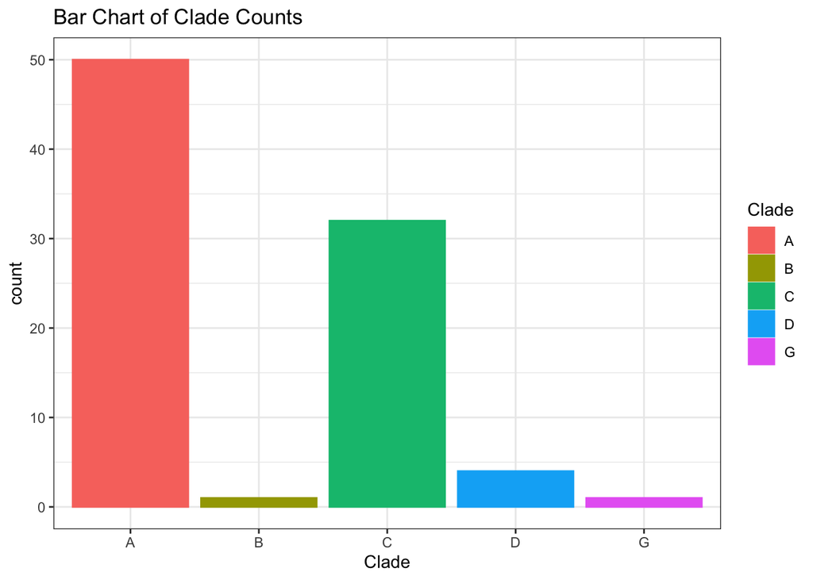

```r
algae_coral_clade_maj %>%
  ggplot(aes(x = Clade, color = Clade, fill = Clade)) +
  geom_bar() +
  theme_bw() +
  ggtitle("Bar Chart of Clade Counts")
```

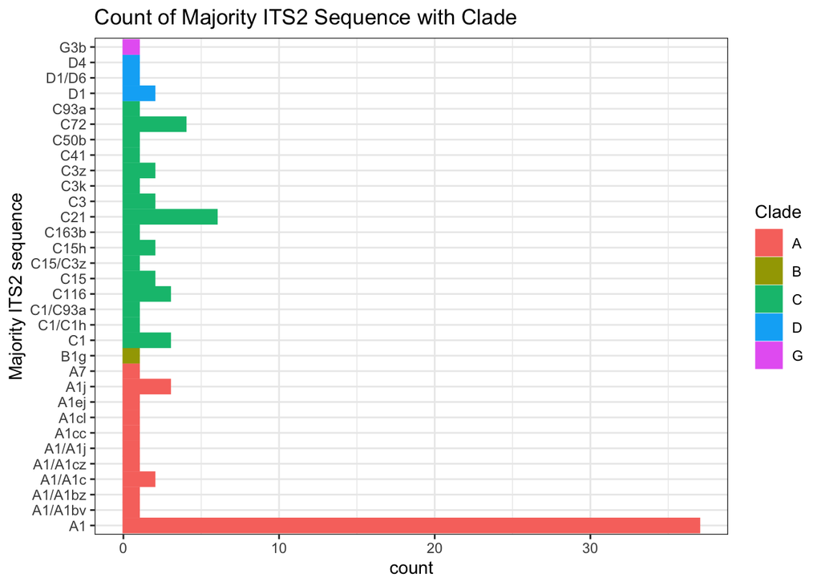

```r
algae_coral_clade_maj %>%
  ggplot(aes(x = `Majority ITS2 sequence`, color = Clade, fill = Clade)) +
  geom_histogram(stat="count") +
  theme_bw() +
  ggtitle("Count of Majority ITS2 Sequence with Clade") +
  coord_flip()
```

- Need to pivot back with samples as rows

```r
algae_coral_clade_maj %>%
  # take out associated psecies column for now
  select(-`Associated species`) %>%
  # there are two ITS2 columns each of a diff data type
  # only need the one that is numeric
  select(-ITS2) %>%
  # simplify the pivot by taking out the longer profile (analysis first on clade)
  select(-`ITS2 type profile`) %>%
  # simply names
  rename(ITS2 = `ITS2 type profile UID`,
         Majority = `Majority ITS2 sequence`) %>%
  # check names
 # names()
  # pivot back to have samples as rows
  pivot_longer(cols = 1:659) %>%
  # rename 'name' and 'value' to be clearer
  rename(sample_id = name,
         its2_count = value) %>%
  # arrange by sample name
  arrange(sample_id) -> algae_df

## Quality Checks:
  # # group by sample name to check info per sample
  # group_by(name) %>%
  # summarize(n = n()) #%>% # yes, there are 88 ITS2 types and each sample has 88


glimpse(algae_df)
```

```
## Rows: 57,992
## Columns: 5
## $ ITS2       <dbl> 85586, 85581, 84568, 85591, 84566, 85585, 85596, 84552, 846…
## $ Clade      <chr> "A", "A", "A", "A", "A", "A", "A", "A", "A", "A", "A", "A",…
## $ Majority   <chr> "A1", "A1", "A1/A1c", "A1", "A1", "A1/A1c", "A1", "A1", "A1…
## $ sample_id  <chr> "PDOG-R1-1", "PDOG-R1-1", "PDOG-R1-1", "PDOG-R1-1", "PDOG-R…
## $ its2_count <dbl> 0, 0, 21483, 0, 0, 0, 0, 0, 0, 0, 0, 0, 0, 0, 0, 0, 0, 0, 0…
```

## Compare new data frame with original for data quality check

- Randomly picking 3 sample names to check with original algae table

```r
algae_df %>%
 # filter(sample_id=="PDOG-R1-1") # yes, this is right
  #filter(sample_id=="PWAJ-R3-10") # yes this is right
  filter(sample_id=="PWAJ-R1-6") # yes, this is right
```

```
## # A tibble: 88 × 5
##     ITS2 Clade Majority sample_id its2_count
##    <dbl> <chr> <chr>    <chr>          <dbl>
##  1 85586 A     A1       PWAJ-R1-6          0
##  2 85581 A     A1       PWAJ-R1-6      25522
##  3 84568 A     A1/A1c   PWAJ-R1-6          0
##  4 85591 A     A1       PWAJ-R1-6          0
##  5 84566 A     A1       PWAJ-R1-6          0
##  6 85585 A     A1/A1c   PWAJ-R1-6          0
##  7 85596 A     A1       PWAJ-R1-6          0
##  8 84552 A     A1       PWAJ-R1-6          0
##  9 84603 A     A1       PWAJ-R1-6          0
## 10 84604 A     A1/A1cz  PWAJ-R1-6          0
## # ℹ 78 more rows
```

## More quality checks before creating new columns for region, reef, species

Yes, there are 659 groups of `sample_id` Yes, there are 88 unique ITS2 codes

```r
algae_df %>%
  group_by(sample_id) # yes 659 unique
```

```
## # A tibble: 57,992 × 5
## # Groups:   sample_id [659]
##     ITS2 Clade Majority sample_id its2_count
##    <dbl> <chr> <chr>    <chr>          <dbl>
##  1 85586 A     A1       PDOG-R1-1          0
##  2 85581 A     A1       PDOG-R1-1          0
##  3 84568 A     A1/A1c   PDOG-R1-1      21483
##  4 85591 A     A1       PDOG-R1-1          0
##  5 84566 A     A1       PDOG-R1-1          0
##  6 85585 A     A1/A1c   PDOG-R1-1          0
##  7 85596 A     A1       PDOG-R1-1          0
##  8 84552 A     A1       PDOG-R1-1          0
##  9 84603 A     A1       PDOG-R1-1          0
## 10 84604 A     A1/A1cz  PDOG-R1-1          0
## # ℹ 57,982 more rows
```

```r
algae_df %>%
  group_by(ITS2) # yes 88 unique
```

```
## # A tibble: 57,992 × 5
## # Groups:   ITS2 [88]
##     ITS2 Clade Majority sample_id its2_count
##    <dbl> <chr> <chr>    <chr>          <dbl>
##  1 85586 A     A1       PDOG-R1-1          0
##  2 85581 A     A1       PDOG-R1-1          0
##  3 84568 A     A1/A1c   PDOG-R1-1      21483
##  4 85591 A     A1       PDOG-R1-1          0
##  5 84566 A     A1       PDOG-R1-1          0
##  6 85585 A     A1/A1c   PDOG-R1-1          0
##  7 85596 A     A1       PDOG-R1-1          0
##  8 84552 A     A1       PDOG-R1-1          0
##  9 84603 A     A1       PDOG-R1-1          0
## 10 84604 A     A1/A1cz  PDOG-R1-1          0
## # ℹ 57,982 more rows
```

#### Create columns with other categorical data of region, reef, and species

- This is easier than joining with metadata because sample names already have species, region, and reef within acronyms
- Save as `algae_df`

```r
algae_df %>%
  # extract letter P or S at beginning of sample name for which species
  mutate(species = str_sub(sample_id, 1, 1),
         region = str_sub(sample_id, 2,4),
         reef = str_sub(sample_id, 6,7)) %>%
  # ITS2 id should be a categorical not a double
  mutate(ITS2 = as.character(ITS2))-> algae_df
```

```r
glimpse(algae_df)
```

```
## Rows: 57,992
## Columns: 8
## $ ITS2       <chr> "85586", "85581", "84568", "85591", "84566", "85585", "8559…
## $ Clade      <chr> "A", "A", "A", "A", "A", "A", "A", "A", "A", "A", "A", "A",…
## $ Majority   <chr> "A1", "A1", "A1/A1c", "A1", "A1", "A1/A1c", "A1", "A1", "A1…
## $ sample_id  <chr> "PDOG-R1-1", "PDOG-R1-1", "PDOG-R1-1", "PDOG-R1-1", "PDOG-R…
## $ its2_count <dbl> 0, 0, 21483, 0, 0, 0, 0, 0, 0, 0, 0, 0, 0, 0, 0, 0, 0, 0, 0…
## $ species    <chr> "P", "P", "P", "P", "P", "P", "P", "P", "P", "P", "P", "P",…
## $ region     <chr> "DOG", "DOG", "DOG", "DOG", "DOG", "DOG", "DOG", "DOG", "DO…
## $ reef       <chr> "R1", "R1", "R1", "R1", "R1", "R1", "R1", "R1", "R1", "R1",…
```

# Plots

## Quick snapshot of main variables with colors by Clade

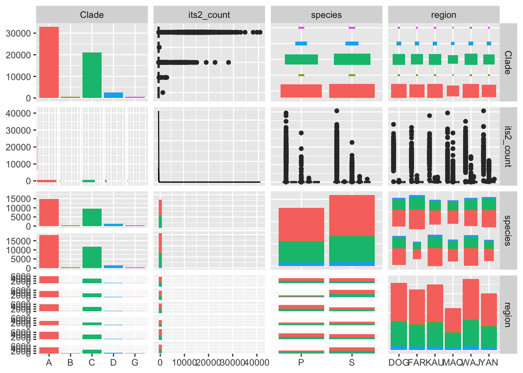

```r
GGally::ggpairs(select(algae_df, -1, -3, -4, -8), mapping = aes(color = Clade)) -> ggpairs_color_clade
ggpairs_color_clade
```

- Saving plot

```r
ggsave("GGpairs_color_clade.png", ggpairs_color_clade, device = "png",
       path = "../plots")
```

## Quick snapshot of main variables with colors by Species

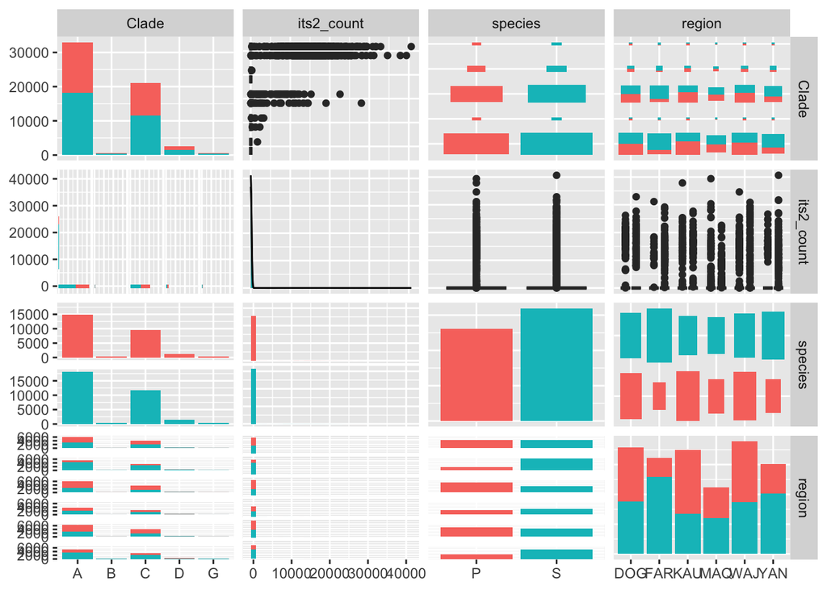

```r
GGally::ggpairs(select(algae_df, -1, -3, -4, -8), mapping = aes(color = species)) -> ggpairs_color_species

ggpairs_color_species
```

- Saving plot

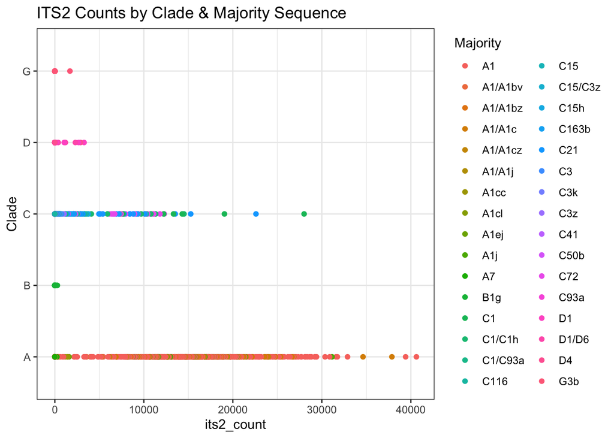

```r
ggsave("GGpairs_color_species.png", ggpairs_color_species, device = "png", path = "../plots")
algae_df %>%
  arrange(-its2_count) %>%
  ggplot(aes(x = its2_count, y = Clade, color = Majority )) +
  geom_point() +
  theme_bw() +
  ggtitle("ITS2 Counts by Clade & Majority Sequence")
```

### Scatter Plot(s)

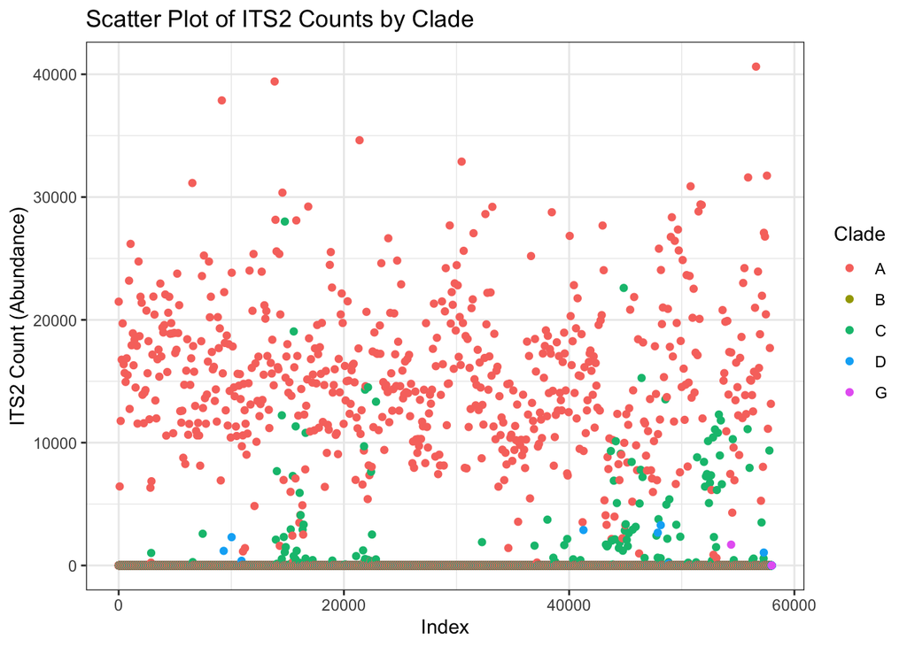

```r
#plot(algae_df$its2_count)

ggplot(algae_df, aes(x = 1:nrow(algae_df), y = its2_count, color = Clade)) +  # use nrow function to have the index values on the x axis
  geom_point() +
  theme_bw() +
  xlab("Index") +
  ylab("ITS2 Count (Abundance)") +
  ggtitle("Scatter Plot of ITS2 Counts by Clade") -> scatter_its2

scatter_its2
```

```r
ggsave("scatter_its2.png", scatter_its2, device = "png", path = "../plots")
```

- What if I were to log the count variable?

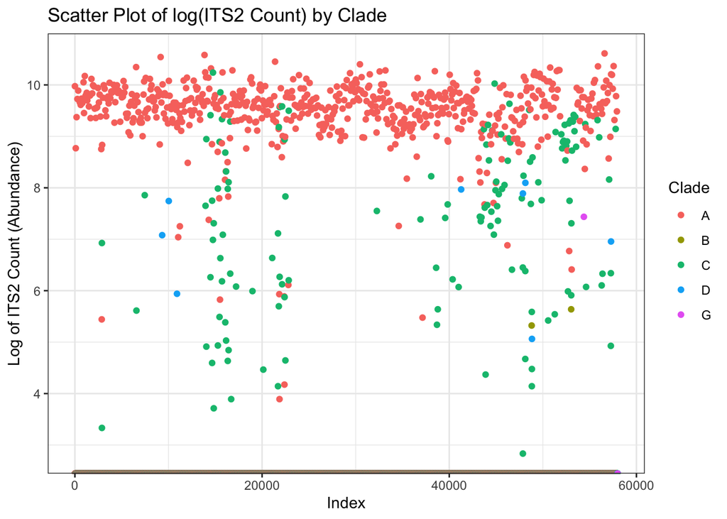

```r
ggplot(algae_df, aes(x = 1:nrow(algae_df), y = log(its2_count), color = Clade)) +  # use nrow function to have the index values on the x axis
  geom_point() +
  theme_bw() +
  xlab("Index") +
  ylab("Log of ITS2 Count (Abundance)") +
  ggtitle("Scatter Plot of log(ITS2 Count) by Clade")
```

### What does data frame look like if I filter out ITS2 counts that are 0?

- Compare with similar plot

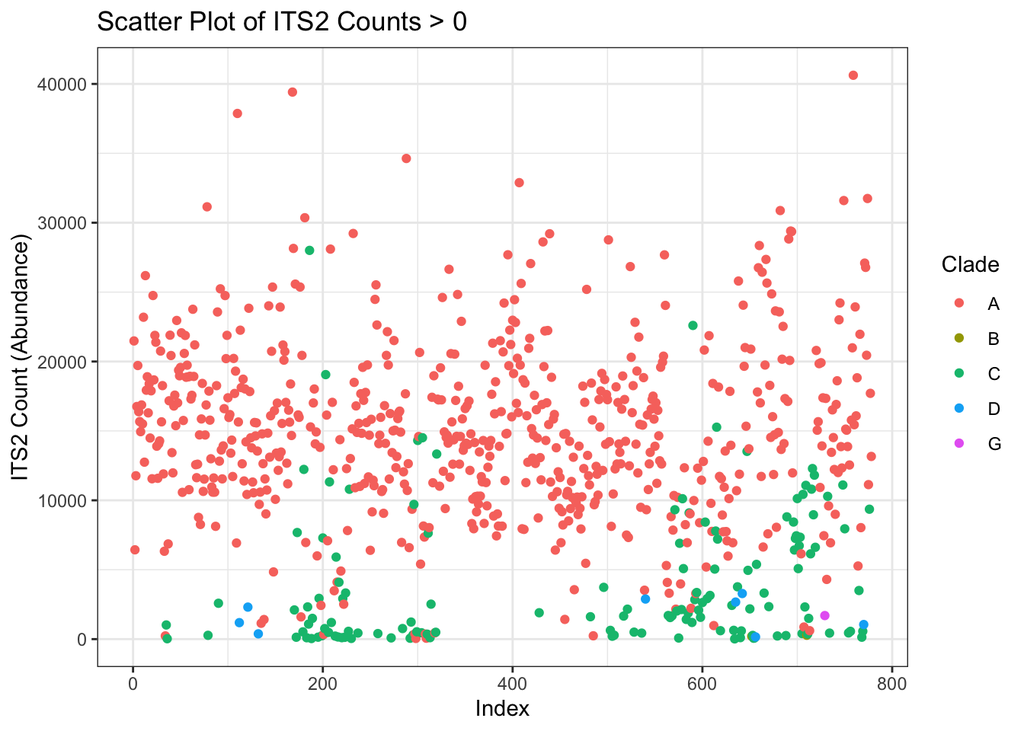

```r
algae_df %>%
  filter(its2_count >0) %>% # 778 rows x 8
  ggplot(aes(x = 1:nrow(.), y = its2_count, color = Clade)) +  # use nrow function to have the index values on the x axis
  geom_point() +
  theme_bw() +
  xlab("Index") +
  ylab("ITS2 Count (Abundance)") +
  ggtitle("Scatter Plot of ITS2 Counts > 0") -> scatter_its2_gr_0

scatter_its2_gr_0
```

```r
ggsave("scatter_its2_gr_0.png", scatter_its2_gr_0, device = "png", path = "../plots")
```

- From the above, it may be useful to test with Clade A first

### Plots for Majority Sequence

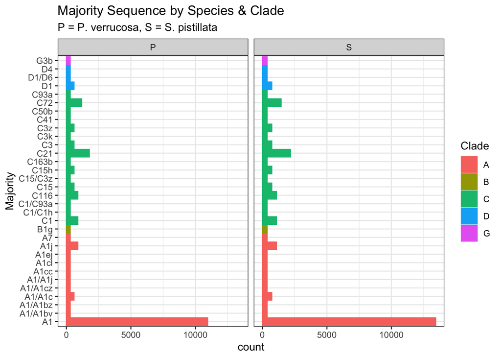

```r
algae_df %>%
  group_by(Majority) %>% # 32 groups
  ggplot(aes(y = Majority, color = Clade, fill = Clade)) +
  geom_bar() +
  facet_wrap(~species) +
  theme_bw() +
  ggtitle("Majority Sequence by Species & Clade", "P = P. verrucosa, S = S. pistillata") -> plot_ct_maj_clade_species


plot_ct_maj_clade_species
```

```r
ggsave("Plot_ct_maj_clade_species.png", device = "png", path = "../plots")
```

### Number of rows per species per clade

- How are observations (rows) split between species and clade if Clade A is used for testing? Or if minor clades are filtered out?

```r
algae_df %>%
  # filter out 0 values to see actual sequencing info
  filter(its2_count > 0) %>%  # 778 observations with actual non-zero info
  group_by(species, Clade) %>%
  summarise(n = n()) %>%
  arrange(-n)
```

```
## # A tibble: 8 × 3
## # Groups:   species [2]
##   species Clade     n
##   <chr>   <chr> <int>
## 1 S       A       328
## 2 P       A       300
## 3 S       C        86
## 4 P       C        53
## 5 S       D         5
## 6 P       D         3
## 7 S       B         2
## 8 S       G         1
```

- It is important to note that as of 10-30-2023, the client is requesting to focus on clade C and this clade has only 86 observations in species S and 53 in species P.
- It is also worth mentioning in final report that future research may want to focus on sampling and sequencing for the under-represented clades.
- When grouping by sample ID and Clade, many samples have 50 rows of Clade A, 32 or so of Clade C, and only 1-4 of the other Clades.
- Within the 50, one sample id has several majority types with different ITS2 types but only one with have any value of count (abundance)

```r
algae_df %>%
  # group by sample id and clade to see how many rows per sample per clade
  group_by(sample_id, Clade) %>%
  # put in order of sample id, then its2 count to see larges to smallest counts per sample id
  arrange( sample_id, -its2_count)
```

```
## # A tibble: 57,992 × 8
## # Groups:   sample_id, Clade [3,295]
##    ITS2  Clade Majority sample_id its2_count species region reef
##    <chr> <chr> <chr>    <chr>          <dbl> <chr>   <chr>  <chr>
##  1 84568 A     A1/A1c   PDOG-R1-1      21483 P       DOG    R1
##  2 85586 A     A1       PDOG-R1-1          0 P       DOG    R1
##  3 85581 A     A1       PDOG-R1-1          0 P       DOG    R1
##  4 85591 A     A1       PDOG-R1-1          0 P       DOG    R1
##  5 84566 A     A1       PDOG-R1-1          0 P       DOG    R1
##  6 85585 A     A1/A1c   PDOG-R1-1          0 P       DOG    R1
##  7 85596 A     A1       PDOG-R1-1          0 P       DOG    R1
##  8 84552 A     A1       PDOG-R1-1          0 P       DOG    R1
##  9 84603 A     A1       PDOG-R1-1          0 P       DOG    R1
## 10 84604 A     A1/A1cz  PDOG-R1-1          0 P       DOG    R1
## # ℹ 57,982 more rows
```

```r
  # summarise(n = n()) %>%
  # arrange(sample_id)
```

- Filter out 0 values to see the rows with sequencing info

```r
algae_df %>%
  arrange(-its2_count) %>%
  filter(its2_count>0) # 778 rows left
```

```
## # A tibble: 778 × 8
##    ITS2  Clade Majority sample_id  its2_count species region reef
##    <chr> <chr> <chr>    <chr>           <dbl> <chr>   <chr>  <chr>
##  1 84607 A     A1       SYAN-R4-18      40624 S       YAN    R4
##  2 84573 A     A1       PMAQ-R1-10      39413 P       MAQ    R1
##  3 85585 A     A1/A1c   PKAU-R1-38      37872 P       KAU    R1
##  4 84568 A     A1/A1c   PWAJ-R3-10      34628 P       WAJ    R3
##  5 84566 A     A1       SDOG-R3-25      32887 S       DOG    R3
##  6 84607 A     A1       SYAN-R4-5       31745 S       YAN    R4
##  7 84607 A     A1       SYAN-R4-10      31597 S       YAN    R4
##  8 84575 A     A1j      PFAR-R3-24      31147 P       FAR    R3
##  9 84552 A     A1       SWAJ-R4-23      30877 S       WAJ    R4
## 10 85595 A     A1       PMAQ-R1-3       30360 P       MAQ    R1
## # ℹ 768 more rows
```

# Write csv file

- Next step is to join with bacteria data, pending questions of perhaps parsing down clades and/or ASVs depending on getting more familiar with ASV table

```r
write_csv(algae_df, "../output/algae_df.csv")
```

# Filtering out ITS2 counts that are 0

- And regraphing to get a quick snapshot since distributions where skewed with so many 0 counts

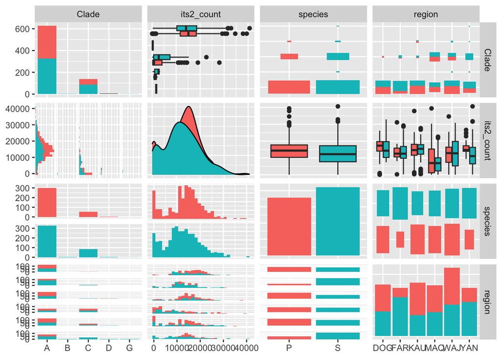

```r
algae_df %>%
  filter(its2_count >0) %>%
  # checking to see how many samples
  group_by(sample_id) %>% # 658 down 1 from 659
  ungroup() -> algae_df_no_
  # redoing plot of the 'quick snapshot' with ggpairs to see distributions
  GGally::ggpairs(algae_df_no_,
                  columns = c(2, 5, 6,7),
                  mapping = aes(color = species))
```